| title: “Untitled” |
| --- |
| author: " " |
| date: “7/15/2021” |
| output: html_document |

```
                          DATA STORY
```

INTRODUCTION

DATA SET

We are provided with a data set called the-counted-2015 from the Guardian. The data is a csv file , it is dataframe consisting of 1146 rows and 14 columns. We will be using this data to solve the problem

• Important field and information

From the data , we have 14 columns. The columns play an important role since we will be using the provided information to solve the problem at hand. The fourteen columns are; uid, name, age, gender, raceethnicity, month, day, year, streetaddress, city, state, classification, lawenforcementagency, armed. From the above 14 columns there are important fields that we will consider during visualizations and statistical analysis which will help us to solve the problem. The important fields include the following columns  
1. Uid 2. Age 3. Gender 4. Raceethnicity 5. State 6. Classification

• Limitations

From the data provided we don’t have some answers to some questions. The following are some of the unanswered questions 1. We are not told the crime committed by the victims. 2. Also there is no column specifying the officer who killed 3. The action taken against the officer who killed also isn’t specified. 4. Reasoning of the officer who killed 5. The reason for the action taken against the victim.

• CLEANING AND WRANGLING

Column renaming: as we explore the data we get long descriptive column names, since we want precise and short column names we rename the columns to give it a better meaning

Checking for missing values: in this step , we check for missing values in each column

Omitting the missing values: using the R command na.omit , we remove the missing values

Changing the age column in to a number : since age is a number not a character , we have to change it in to a number

Looking for outliers: we use a boxplot to check for outliers which they exist on the boxplot concerning age. We can try omit the outliers for better visualization and results

View the clean data for further cleaning: we view the cleaned data to see if we can do more. Since the data Is ready and clean we stop here

EXPLORATORY DATA ANALYSIS AND SOME IMPORTANT VISUALIZATIONS

setting working directory

```r
setwd("C:/project 001")
library(readr)
the_counted_2015= read_csv("the-counted-2015.csv")
```

importing libraries

```r
library(tidyr)
library(tidyverse)
```

```r
library(ggplot2)
```

data cleaning

```r
glimpse(the_counted_2015)
```

```
## Rows: 1,146
## Columns: 14
## $ uid                  <dbl> 2, 4, 5, 6, 7, 8, 9, 10, 11, 12, 13, 14, 15, 16, ~
## $ name                 <chr> "Matthew Ajibade", "Lewis Lembke", "Michael Koche~
## $ age                  <chr> "22", "47", "19", "23", "53", "32", "22", "39", "~
## $ gender               <chr> "Male", "Male", "Male", "Male", "Male", "Male", "~
## $ raceethnicity        <chr> "Black", "White", "White", "Hispanic/Latino", "As~
## $ month                <chr> "January", "January", "January", "January", "Janu~
## $ day                  <dbl> 1, 2, 3, 3, 2, 4, 5, 5, 6, 6, 6, 6, 6, 7, 7, 7, 8~
## $ year                 <dbl> 2015, 2015, 2015, 2015, 2015, 2015, 2015, 2015, 2~
## $ streetaddress        <chr> "1050 Carl Griffin Dr", "4505 SW Masters Loop", "~
## $ city                 <chr> "Savannah", "Aloha", "Kaumakani", "Wichita", "She~
## $ state                <chr> "GA", "OR", "HI", "KS", "WA", "CA", "AZ", "CO", "~
## $ classification       <chr> "Death in custody", "Gunshot", "Struck by vehicle~
## $ lawenforcementagency <chr> "Chatham County Sheriff's Office", "Washington Co~
## $ armed                <chr> "No", "Firearm", "No", "No", "Firearm", "Non-leth~
```

```r
names(the_counted_2015)
```

```
##  [1] "uid"                  "name"                 "age"
##  [4] "gender"               "raceethnicity"        "month"
##  [7] "day"                  "year"                 "streetaddress"
## [10] "city"                 "state"                "classification"
## [13] "lawenforcementagency" "armed"
```

```r
dim(the_counted_2015)
```

```
## [1] 1146   14
```

```r
names(the_counted_2015)[5]= "race"
names(the_counted_2015)[9]= "adress"
names(the_counted_2015)[12]="cause_of_death"
names(the_counted_2015)[13]="jurisdiction"
names(the_counted_2015)[1]= "id"
names(the_counted_2015)
```

```
##  [1] "id"             "name"           "age"            "gender"
##  [5] "race"           "month"          "day"            "year"
##  [9] "adress"         "city"           "state"          "cause_of_death"
## [13] "jurisdiction"   "armed"
```

```r
sum(is.na(the_counted_2015$id))
```

```
## [1] 0
```

```r
sum(is.na(the_counted_2015$name))
```

```
## [1] 0
```

```r
sum(is.na(the_counted_2015$age))
```

```
## [1] 0
```

```r
sum(is.na(the_counted_2015$gender))
```

```
## [1] 0
```

```r
sum(is.na(the_counted_2015$race))
```

```
## [1] 0
```

```r
sum(is.na(the_counted_2015$month))
```

```
## [1] 0
```

```r
sum(is.na(the_counted_2015$day))
```

```
## [1] 0
```

```r
sum(is.na(the_counted_2015$year))
```

```
## [1] 0
```

```r
sum(is.na(the_counted_2015$adress))
```

```
## [1] 6
```

```r
sum(is.na(the_counted_2015$city))
```

```
## [1] 0
```

```r
sum(is.na(the_counted_2015$state))
```

```
## [1] 0
```

```r
sum(is.na(the_counted_2015$cause_of_death))
```

```
## [1] 0
```

```r
sum(is.na(the_counted_2015$jurisdiction))
```

```
## [1] 0
```

```r
sum(is.na(the_counted_2015$armed))
```

```
## [1] 0
```

```r
my_data_new=na.omit(the_counted_2015)
names(my_data_new)
```

```
##  [1] "id"             "name"           "age"            "gender"
##  [5] "race"           "month"          "day"            "year"
##  [9] "adress"         "city"           "state"          "cause_of_death"
## [13] "jurisdiction"   "armed"
```

```r
my_data_new= my_data_new %>% mutate(age=as.numeric(age))
str(my_data_new)
```

```
## tibble [1,140 x 14] (S3: tbl_df/tbl/data.frame)
##  $ id            : num [1:1140] 2 4 5 6 7 8 9 10 11 12 ...
##  $ name          : chr [1:1140] "Matthew Ajibade" "Lewis Lembke" "Michael Kocher Jr" "John Quintero" ...
##  $ age           : num [1:1140] 22 47 19 23 53 32 22 39 25 26 ...
##  $ gender        : chr [1:1140] "Male" "Male" "Male" "Male" ...
##  $ race          : chr [1:1140] "Black" "White" "White" "Hispanic/Latino" ...
##  $ month         : chr [1:1140] "January" "January" "January" "January" ...
##  $ day           : num [1:1140] 1 2 3 3 2 4 5 5 6 6 ...
##  $ year          : num [1:1140] 2015 2015 2015 2015 2015 ...
##  $ adress        : chr [1:1140] "1050 Carl Griffin Dr" "4505 SW Masters Loop" "2600 Kaumualii Hwy" "500 North Oliver Ave" ...
##  $ city          : chr [1:1140] "Savannah" "Aloha" "Kaumakani" "Wichita" ...
##  $ state         : chr [1:1140] "GA" "OR" "HI" "KS" ...
##  $ cause_of_death: chr [1:1140] "Death in custody" "Gunshot" "Struck by vehicle" "Gunshot" ...
##  $ jurisdiction  : chr [1:1140] "Chatham County Sheriff's Office" "Washington County Sheriff's Office" "Kauai Police Department" "Wichita Police Department" ...
##  $ armed         : chr [1:1140] "No" "Firearm" "No" "No" ...
##  - attr(*, "na.action")= 'omit' Named int [1:6] 89 269 332 353 915 1124
##   ..- attr(*, "names")= chr [1:6] "89" "269" "332" "353" ...
```

CHANGING CHARACTERS TO FACTORS FOR SOME ANALYSIS

```r
my_data_new=my_data_new %>% mutate(gender=factor(gender), cause_of_death=factor(cause_of_death),state=factor(state), cause_of_death=factor(cause_of_death))
glimpse(my_data_new)
```

```
## Rows: 1,140
## Columns: 14
## $ id             <dbl> 2, 4, 5, 6, 7, 8, 9, 10, 11, 12, 13, 14, 15, 16, 17, 18~
## $ name           <chr> "Matthew Ajibade", "Lewis Lembke", "Michael Kocher Jr",~
## $ age            <dbl> 22, 47, 19, 23, 53, 32, 22, 39, 25, 26, 34, 35, 47, 30,~
## $ gender         <fct> Male, Male, Male, Male, Male, Male, Male, Male, Male, M~
## $ race           <chr> "Black", "White", "White", "Hispanic/Latino", "Asian/Pa~
## $ month          <chr> "January", "January", "January", "January", "January", ~
## $ day            <dbl> 1, 2, 3, 3, 2, 4, 5, 5, 6, 6, 6, 6, 6, 7, 7, 7, 8, 7, 8~
## $ year           <dbl> 2015, 2015, 2015, 2015, 2015, 2015, 2015, 2015, 2015, 2~
## $ adress         <chr> "1050 Carl Griffin Dr", "4505 SW Masters Loop", "2600 K~
## $ city           <chr> "Savannah", "Aloha", "Kaumakani", "Wichita", "Shelton",~
## $ state          <fct> GA, OR, HI, KS, WA, CA, AZ, CO, CA, CA, IA, KS, PA, IA,~
## $ cause_of_death <fct> Death in custody, Gunshot, Struck by vehicle, Gunshot, ~
## $ jurisdiction   <chr> "Chatham County Sheriff's Office", "Washington County S~
## $ armed          <chr> "No", "Firearm", "No", "No", "Firearm", "Non-lethal fir~
```

DEATH RATES BY POLICE ACCORDING TO GENDER

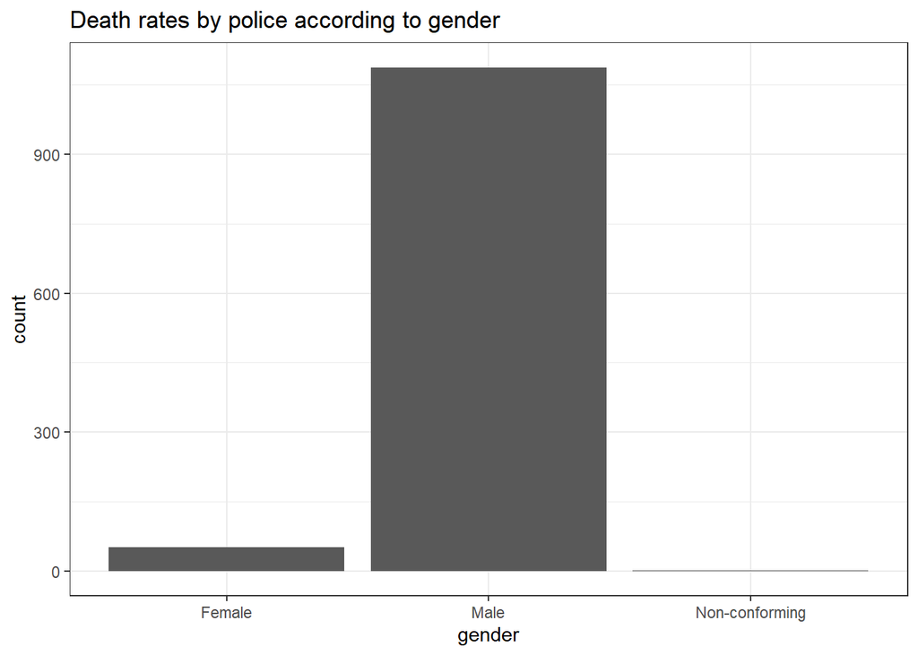

```r
my_data_new %>% ggplot(aes(gender)) + geom_bar()+theme_bw() +labs(title = "Death rates by police according to gender")
```

from the above we clearly see that most affected gender is male. males are the most victims in the police kiling

DEATH RATES BY POLICE ACCORDING TO RACE

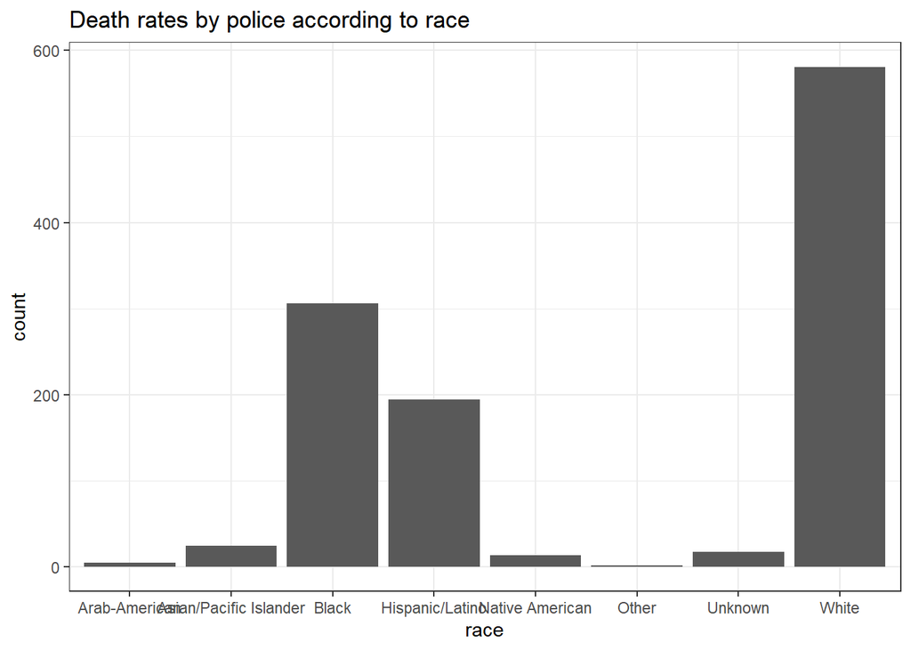

```r
my_data_new %>% ggplot(aes(race)) + geom_bar()+theme_bw() +labs(title = "Death rates by police according to race")
```

clearly we can see that the most affected origin is the whites, followed by blacks ,then latinos as the others preceed

DEATH RATES BY POLICE ACCORDING TO CAUSE_OF_DEATH

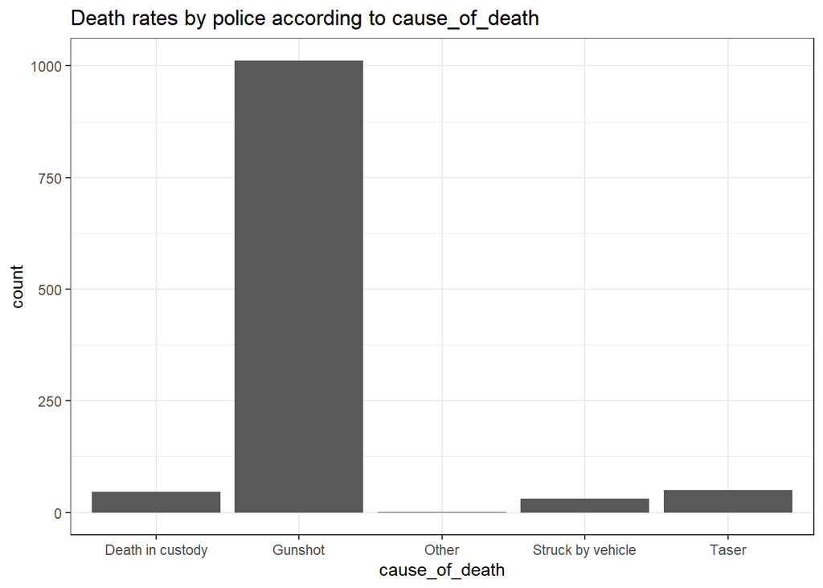

```r
my_data_new %>% ggplot(aes(cause_of_death)) + geom_bar()+theme_bw() +labs(title = "Death rates by police according to cause_of_death")
```

from the plot above we can conclude that most of the police killings is by gunshots , followed by teasers, others died in custody and others struck by a vehicle

DEATH RATES BY POLICE ACCORDING TO AGE

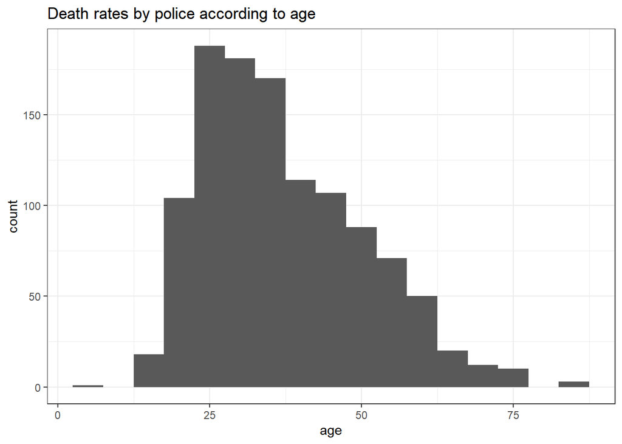

```r
my_data_new %>% ggplot(aes(age)) + geom_histogram(binwidth = 5)+theme_bw() +labs(title = "Death rates by police according to age")
```

we can see that the most affected age is beetween 25-50

DEATH RATES BY POLICE ACCORDING TO STATES

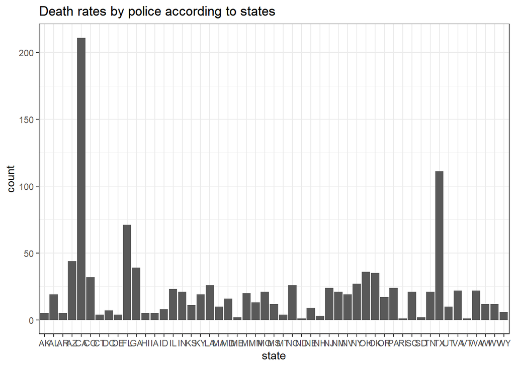

```r
my_data_new %>% ggplot(aes(state)) + geom_bar()+theme_bw() +labs(title = "Death rates by police according to states")
```

the most affected states are; california,texas,florida, arizona,georgia,ohio, oklahoma ,as the others preceed

PROPORTION OF GENDER

```r
 prop.table(table(my_data_new$gender))
```

```
##
##         Female           Male Non-conforming
##    0.044736842    0.954385965    0.000877193
```

we clearly see that a bigger proportion is on males signifying that a bigger percentage of the victims are male

```r
prop.table(table(my_data_new$origin))
```

```
## numeric(0)
```

CHECKING FOR OUTLIERS USING BOXPLOTS

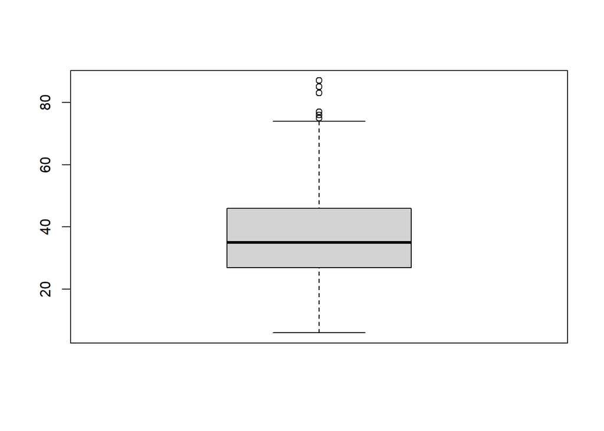

```r
boxplot(my_data_new$age)
```

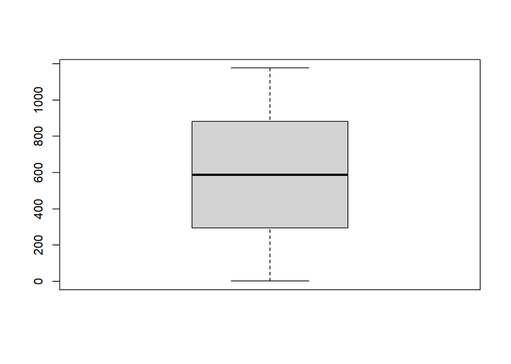

```r
boxplot(my_data_new$id)
```

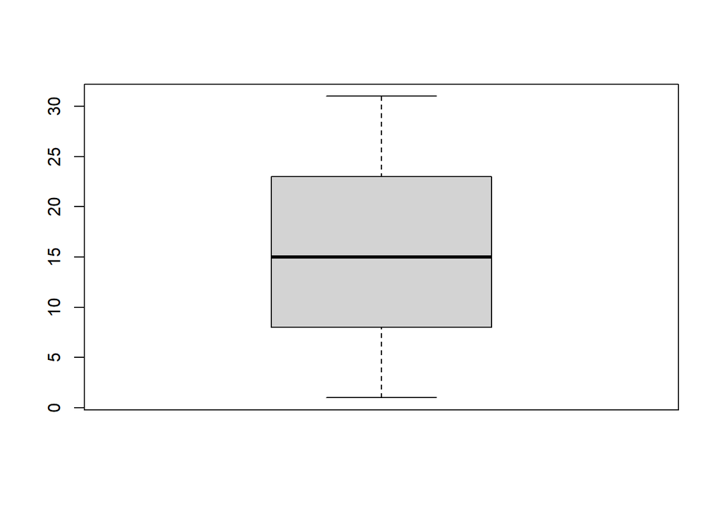

```r
boxplot(my_data_new$day)
```

clearly there are some outliers with the age variale

CONCLUSION